# DigitalAgri - Tarea Fundamentos de R

Alberto Gómez Juan

10/12/2021

## Introducción

España es el primer país productor de aceitunas de mesa del mundo, seguido por Egipto, Turquía, Argelia, Grecia, Siria, Marruecos, Perú y Argentina. La producción media mundial de las últimas cinco campañas asciende a 2.847.700 toneladas, de las cuales 561.100 se produjeron en España, es decir, el 19,7% del total[^1].

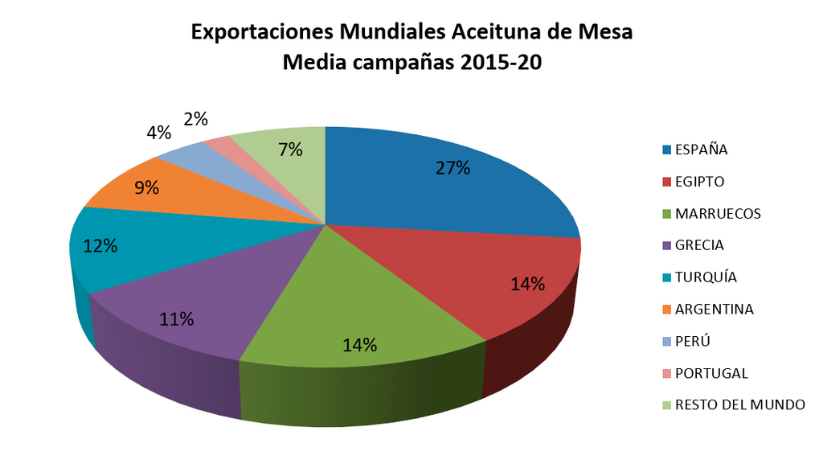

Fuente: Consejo Oleícola Internacional

## Metodología

Para empezar se incluyen las librerias utilizadas para el analisis de los datos:

```r
# Importar las librerias utilizadas
library(tidyverse)
library(cowplot)
library(ggplot2)
library(dplyr)

#Gráficos de correlación
library(PerformanceAnalytics)
```

Seguido a esto, se leen los datos de desde archivos CSV para conformar un dataset con los datos organizados para los procedimientos estadísticos.

```r
# Lectura de datos a partir de un archivo CSV.
areacosechada_origen <- read.csv("datos/FAOSTAT_data_12-18-2021_area.csv")
rendimiento_origen <- read.csv("datos/FAOSTAT_data_12-18-2021_rendimiento.csv")
produccion_origen <- read.csv("datos/FAOSTAT_data_12-18-2021_produccion.csv")
exportaciones_origen <- read.csv("datos/FAOSTAT_data_12-18-2021_exportaciones.csv")
```

Se realiza la limpieza de los datos para extraer unicamente los necesarios y se descarta el resto de información descargada de la FAO.

```r
# Extracción de las columnas correspondientes a cada uno de los datos de interés.
areacosechada <- areacosechada_origen[, c(12)]
rendimiento <- rendimiento_origen[, c(12)]
produccion <- produccion_origen[, c(12)]
exportaciones <- exportaciones_origen[, c(12)]

# Lista de años
anios <- produccion_origen[, c(10)]
```

El nuevo dataframe con la información importante para el análisis se puede ver en la siguiente tabla:

```r
# Convertir en dataframe
olivar <- data.frame(areacosechada, produccion, rendimiento, exportaciones, row.names = anios)

data(olivar)
summary(olivar)
```

```
##  areacosechada       produccion       rendimiento    exportaciones
##  Min.   :1156500   Min.   :1328400   Min.   : 6479   Min.   :  32057
##  1st Qu.:2061500   1st Qu.:2973675   1st Qu.:15124   1st Qu.: 207249
##  Median :2253778   Median :4347046   Median :19178   Median : 409442
##  Mean   :2257193   Mean   :4646455   Mean   :20083   Mean   : 461844
##  3rd Qu.:2471488   3rd Qu.:6008873   3rd Qu.:25380   3rd Qu.: 672981
##  Max.   :2601900   Max.   :9819570   Max.   :38075   Max.   :1120699
```

```r
head(olivar, 3)
```

```
##      areacosechada produccion rendimiento exportaciones
## 1980       1156500    2255000       19498        121406
## 1981       2045000    1520800        7437         55495
## 1982       2045800    3337900       16316         32057
```

```r
tail(olivar, 3)
```

```
##      areacosechada produccion rendimiento exportaciones
## 2017       2554829    6549499       25636        944462
## 2018       2579000    9819570       38075        902210
## 2019       2601900    5965080       22926       1075727
```

Se grafica cada conjunto de datos en diagramas de caja y bigote.

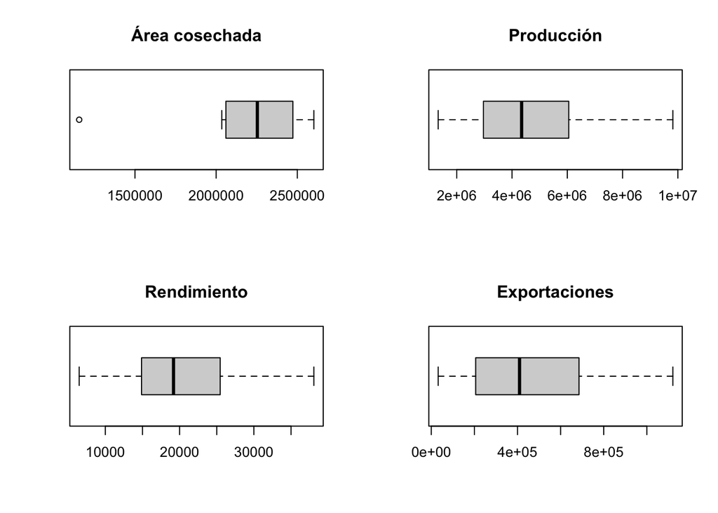

```r
# Graficar en dos columnas y dos filas
par(mfrow=c(2, 2))

# boxplot
boxplot(olivar$areacosechada, main="Área cosechada", horizontal = TRUE)
boxplot(olivar$produccion, main="Producción", horizontal = TRUE)
boxplot(olivar$rendimiento, main="Rendimiento", horizontal = TRUE)
boxplot(olivar$exportaciones, main="Exportaciones", horizontal = TRUE)
```

Se observa que existe un dato atípico que posiblemente se deba a un error en los datos de área cosechada, por lo cual se retira del conjunto de datos.

```r
# Eliminación de datos atípicos
olivar <- subset(olivar, areacosechada != 1156500)
anios <- anios[2:40]
```

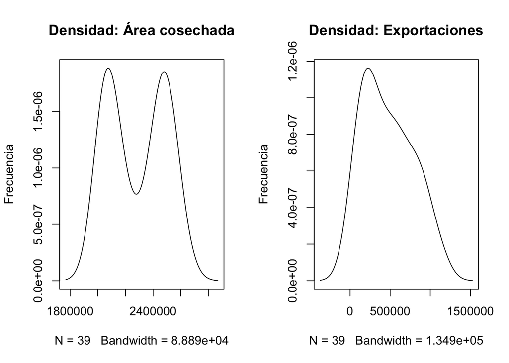

```r
#Distribución de densidad
par(mfrow=c(1, 2))
plot(density(olivar$areacosechada), main="Densidad: Área cosechada", ylab="Frecuencia")
plot(density(olivar$exportaciones), main="Densidad: Exportaciones", ylab="Frecuencia")
```

## Gráficas

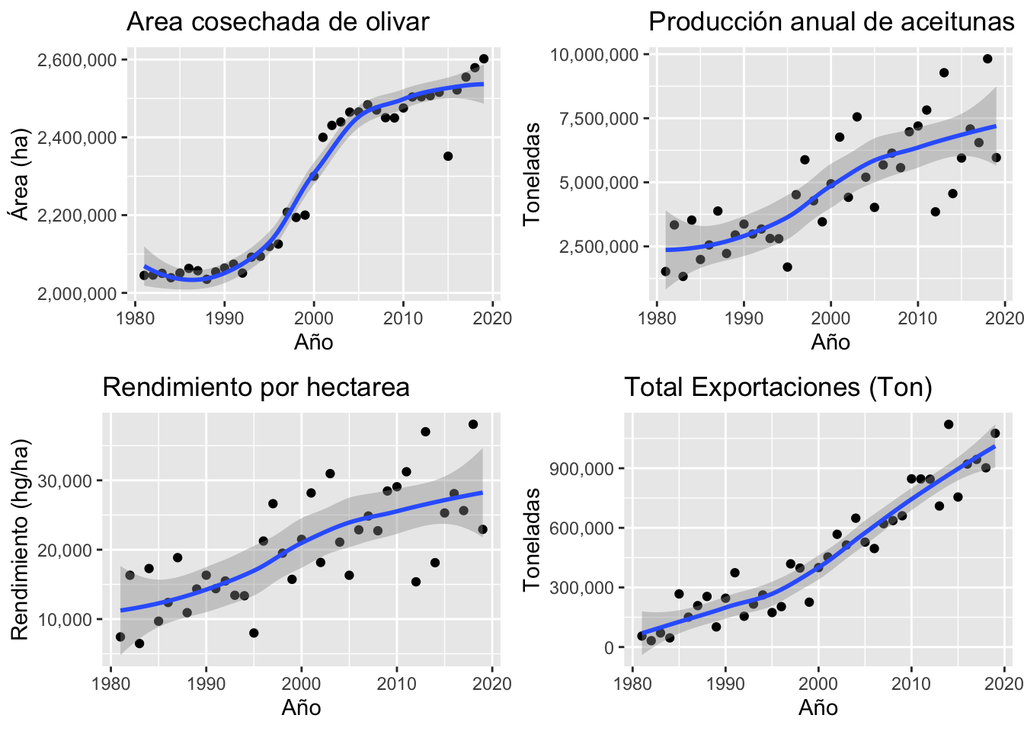

## Interpretación de resultados

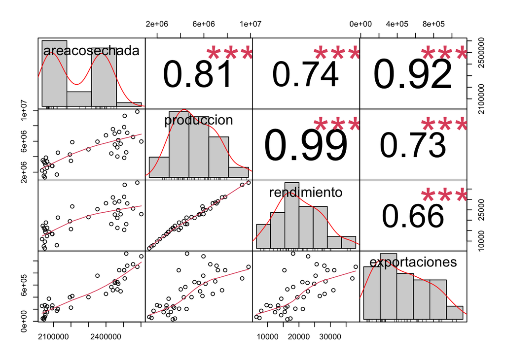

```r
#Gráficos de correlación
chart.Correlation(olivar)
```

```r
modelo <- lm(exportaciones~areacosechada+produccion+rendimiento, data = olivar)
summary(modelo)
```

```
##
## Call:
## lm(formula = exportaciones ~ areacosechada + produccion + rendimiento,
##     data = olivar)
##
## Residuals:
##     Min      1Q  Median      3Q     Max
## -253453  -87280  -13554   82137  321856
##
## Coefficients:
##                 Estimate Std. Error t value Pr(>|t|)
## (Intercept)   -2.627e+06  7.509e+05  -3.498 0.001295 **
## areacosechada  1.366e+00  3.360e-01   4.066 0.000258 ***
## produccion     3.504e-02  1.688e-01   0.208 0.836757
## rendimiento   -9.467e+00  3.998e+01  -0.237 0.814193
## ---
## Signif. codes:  0 '***' 0.001 '**' 0.01 '*' 0.05 '.' 0.1 ' ' 1
##
## Residual standard error: 127700 on 35 degrees of freedom
## Multiple R-squared:  0.8457, Adjusted R-squared:  0.8324
## F-statistic: 63.92 on 3 and 35 DF,  p-value: 2.801e-14
```

```r
#ggplot(olivar, aes(x = produccion, y = exportaciones)) +
#  geom_point() +
#  stat_smooth() +
#  scale_y_continuous(labels = scales::comma) +
#  ylab("Exportaciones (Ton)")+
#  xlab("Producción (Ton)") +
#  ggtitle("Correlación Exportaciones - Producción")
```

```r
#selección de las mejores variables explicativas
step(modelo,direction = "both")
```

```
## Start:  AIC=920.85
## exportaciones ~ areacosechada + produccion + rendimiento
##
##                 Df  Sum of Sq        RSS    AIC
## - produccion     1 7.0248e+08 5.7128e+11 918.90
## - rendimiento    1 9.1413e+08 5.7149e+11 918.91
## <none>                        5.7058e+11 920.85
## - areacosechada  1 2.6951e+11 8.4008e+11 933.93
##
## Step:  AIC=918.9
## exportaciones ~ areacosechada + rendimiento
##
##                 Df  Sum of Sq        RSS    AIC
## - rendimiento    1 1.5426e+09 5.7282e+11 917.00
## <none>                        5.7128e+11 918.90
## + produccion     1 7.0248e+08 5.7058e+11 920.85
## - areacosechada  1 1.5038e+12 2.0751e+12 967.20
##
## Step:  AIC=917
## exportaciones ~ areacosechada
##
##                 Df  Sum of Sq        RSS    AIC
## <none>                        5.7282e+11 917.00
## + rendimiento    1 1.5426e+09 5.7128e+11 918.90
## + produccion     1 1.3310e+09 5.7149e+11 918.91
## - areacosechada  1 3.1240e+12 3.6969e+12 987.72
```

```
##
## Call:
## lm(formula = exportaciones ~ areacosechada, data = olivar)
##
## Coefficients:
##   (Intercept)  areacosechada
##    -2.718e+06      1.395e+00
```

```r
modelo <- lm(exportaciones~areacosechada, data = olivar)
summary(modelo)
```

```
##
## Call:
## lm(formula = exportaciones ~ areacosechada, data = olivar)
##
## Residuals:
##     Min      1Q  Median      3Q     Max
## -251348  -80264   -9568   77543  328692
##
## Coefficients:
##                 Estimate Std. Error t value Pr(>|t|)
## (Intercept)   -2.718e+06  2.254e+05  -12.06 2.19e-14 ***
## areacosechada  1.395e+00  9.822e-02   14.21  < 2e-16 ***
## ---
## Signif. codes:  0 '***' 0.001 '**' 0.01 '*' 0.05 '.' 0.1 ' ' 1
##
## Residual standard error: 124400 on 37 degrees of freedom
## Multiple R-squared:  0.8451, Adjusted R-squared:  0.8409
## F-statistic: 201.8 on 1 and 37 DF,  p-value: < 2.2e-16
```

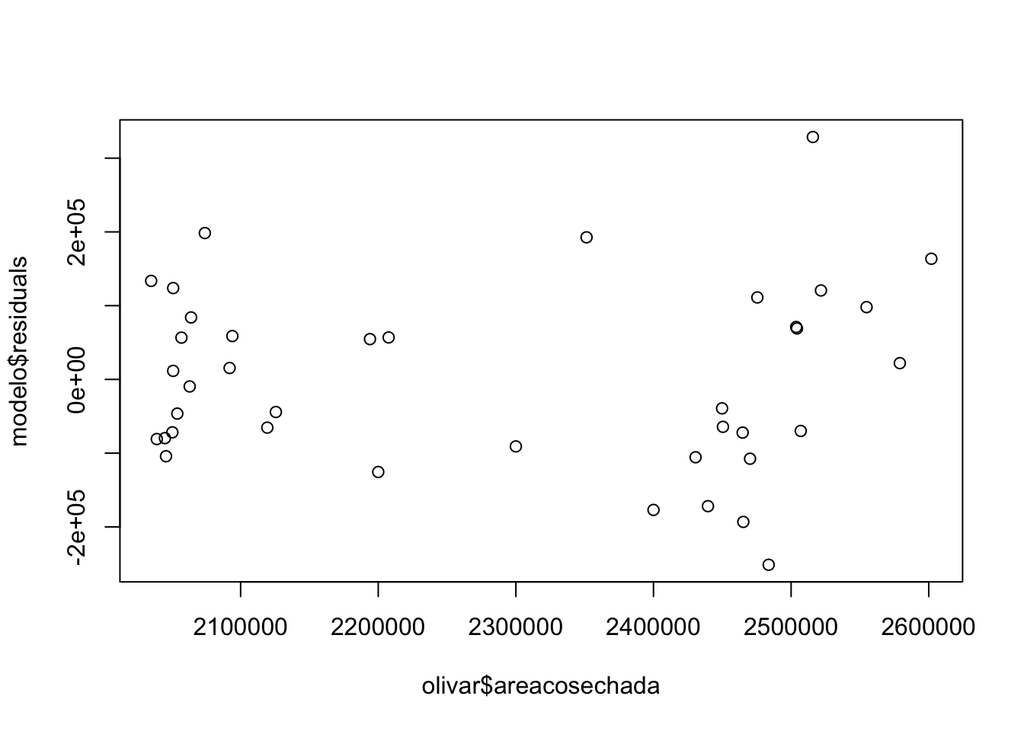

```r
#Validación del modelo

#gráficos dispersión cada variable explicativa y los residuos del modelo
#para ver la linealidad entre variables explicativas y variable respuesta
plot(olivar$areacosechada,modelo$residuals)
```

[^1]: https://asemesa.es/informacion-general-del-sector/